# Wikipedia Articles Scraper

```python
import random
import requests
import sys
import time
import pandas as pd
import wikipedia

data = []
def scrapeArticles(name, count):
    if count == 0:
        sys.exit("Max articles reached")

    page = wikipedia.page(name)
    title = page.title
    print("Article No. {} is {}".format(11 - count, title))
    count -= 1

    all_links = {}
    all_links = page.links
    random.shuffle(all_links)

    # Creates a list of lists containing our data
    data.append([page.title, page.content, page.url])

    # Time between recursive calls to prevent overloading the Wikipedia server with requests
    time.sleep(1)
    scrapeArticles(random.choice(all_links), count)
```

The above script works by using the Wikipedia Library to make a set of links on the original page that is searched. It then randomly picks a link to navigate to, and repeats this process until we reach the maximum number of articles.

```python
scrapeArticles("Formula 1", 10)
```

```
Article No. 1 is Formula One
Article No. 2 is Eisenacher Motorenwerk
Article No. 3 is De Tomaso
Article No. 4 is Ares Design Project1
Article No. 5 is Chevrolet Corvette (C5)
Article No. 6 is International Standard Book Number
Article No. 7 is Collection (publishing)
Article No. 8 is Madrid
Article No. 9 is El Atazar Dam
Article No. 10 is Arch dam
```

```
An exception has occurred, use %tb to see the full traceback.

SystemExit: Max articles reached
```

```python
df = pd.DataFrame(data, columns = ['Page Title', 'Page Content', 'Page URL'])
```

```python
df
```

|  | Page Title | Page Content | Page URL |
| --- | --- | --- | --- |
| 0 | Formula One | Formula One (also known as Formula 1 or F1) is... | https://en.wikipedia.org/wiki/Formula_One |
| 1 | Robert Kubica | Robert Józef Kubica (Polish pronunciation: [ˈr... | https://en.wikipedia.org/wiki/Robert_Kubica |
| 2 | France | France (French: [fʁɑ̃s] (listen)), officially ... | https://en.wikipedia.org/wiki/France |
| 3 | Réunion | Réunion (French: La Réunion [la ʁe.y.njɔ̃] (li... | https://en.wikipedia.org/wiki/R%C3%A9union |
| 4 | Formula One | Formula One (also known as Formula 1 or F1) is... | https://en.wikipedia.org/wiki/Formula_One |
| 5 | Eisenacher Motorenwerk | Eisenacher Motorenwerk (EMW) was an East Germa... | https://en.wikipedia.org/wiki/Eisenacher_Motor... |
| 6 | De Tomaso | De Tomaso Automobili (previously known as De T... | https://en.wikipedia.org/wiki/De_Tomaso |
| 7 | Ares Design Project1 | The Ares Design Project1 is a coach-built spor... | https://en.wikipedia.org/wiki/Ares_Design_Proj... |
| 8 | Chevrolet Corvette (C5) | The Chevrolet Corvette (C5) is the fifth gener... | https://en.wikipedia.org/wiki/Chevrolet_Corvet... |
| 9 | International Standard Book Number | The International Standard Book Number (ISBN) ... | https://en.wikipedia.org/wiki/International_St... |
| 10 | Collection (publishing) | In the field of book publishing, a collection,... | https://en.wikipedia.org/wiki/Collection_(publ... |
| 11 | Madrid | Madrid (, Spanish: [maˈðɾið]) is the capital a... | https://en.wikipedia.org/wiki/Madrid |
| 12 | El Atazar Dam | El Atazar Dam is an arch dam built near Madrid... | https://en.wikipedia.org/wiki/El_Atazar_Dam |
| 13 | Arch dam | An arch dam is a concrete dam that is curved u... | https://en.wikipedia.org/wiki/Arch_dam |

```python
df.head()
```

|  | Page Title | Page Content | Page URL |
| --- | --- | --- | --- |
| 0 | Formula One | Formula One (also known as Formula 1 or F1) is... | https://en.wikipedia.org/wiki/Formula_One |
| 1 | Robert Kubica | Robert Józef Kubica (Polish pronunciation: [ˈr... | https://en.wikipedia.org/wiki/Robert_Kubica |
| 2 | France | France (French: [fʁɑ̃s] (listen)), officially ... | https://en.wikipedia.org/wiki/France |
| 3 | Réunion | Réunion (French: La Réunion [la ʁe.y.njɔ̃] (li... | https://en.wikipedia.org/wiki/R%C3%A9union |
| 4 | Formula One | Formula One (also known as Formula 1 or F1) is... | https://en.wikipedia.org/wiki/Formula_One |

```python
# Return a tuple representing the no. of rows and no. of columns
df.shape
```

```
(14, 3)
```

# Topic Modelling

## Data Cleaning and Pre-Processing

We don't need all the columns in our data frame, when it comes to Topic Modelling we are mainly concerned with the Page Content column. Below we'll make a copy of this column.

```python
#pd.set_option("display.max_colwidth", 100)
new_data = df[['Page Content']].copy()
new_data.head()
```

|  | Page Content |
| --- | --- |
| 0 | Formula One (also known as Formula 1 or F1) is... |
| 1 | Robert Józef Kubica (Polish pronunciation: [ˈr... |
| 2 | France (French: [fʁɑ̃s] (listen)), officially ... |
| 3 | Réunion (French: La Réunion [la ʁe.y.njɔ̃] (li... |
| 4 | Formula One (also known as Formula 1 or F1) is... |

The easiest way for us to make sense of our data is to create a few visualizations of our data. The first visualization we can create is a bar chart representing the frequency of words in our data. I followed this [blog](https://www.analyticsvidhya.com/blog/2018/10/mining-online-reviews-topic-modeling-lda/).

```python
import nltk
from nltk import FreqDist
import matplotlib.pyplot as plt
import seaborn as sns

# function to plot most frequent terms
def freq_words(x, terms = 30):
  all_words = ' '.join([text for text in x])
  all_words = all_words.split()

  fdist = FreqDist(all_words)
  words_df = pd.DataFrame({'word':list(fdist.keys()), 'count':list(fdist.values())})

  # selecting top 20 most frequent words
  d = words_df.nlargest(columns="count", n = terms)
  plt.figure(figsize=(20,5))
  ax = sns.barplot(data=d, x= "word", y = "count")
  ax.set(ylabel = 'Count')
  plt.show()
```

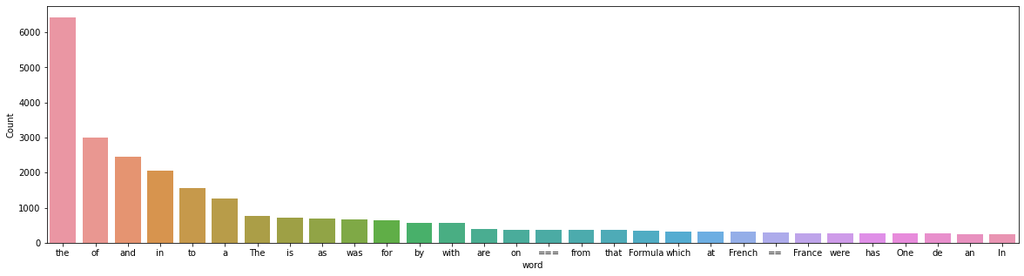

```python
freq_words(new_data['Page Content'])
```

From the bar chart above we can see our most popular words are the, of, and etc. These words are known as *stop words* as they do not add much meaning to the sentences they are in. Let's remove these words are see how the bar chart changes. In addition to this, we can carry out the following [steps](https://towardsdatascience.com/nlp-in-python-data-cleaning-6313a404a470) to further clean our data:

- Removing punctuation
- Tokenizing
- Stemming and Lemmatizing

```python
import string
string.punctuation

def remove_punctuation(text):
    no_punct = []
    for words in text:
        if words not in string.punctuation:
            no_punct.append(words)
    words_no_punct = ''.join(no_punct)
    return words_no_punct
```

This is a function that appends words to a list thus removing any punctuation. We now pass our Pandas Series through this function. The [apply function](https://pandas.pydata.org/pandas-docs/stable/reference/api/pandas.Series.apply.html) does this for us.

```python
new_data['Page Content'] = new_data['Page Content'].apply(lambda x: x.lower())
new_data['Without Punctuation'] = new_data['Page Content'].apply(lambda x: remove_punctuation(x))
new_data.head()
```

|  | Page Content | Without Punctuation |
| --- | --- | --- |
| 0 | formula one (also known as formula 1 or f1) is... | formula one also known as formula 1 or f1 is t... |
| 1 | robert józef kubica (polish pronunciation: [ˈr... | robert józef kubica polish pronunciation ˈrɔbɛ... |
| 2 | france (french: [fʁɑ̃s] (listen)), officially ... | france french fʁɑ̃s listen officially the fren... |
| 3 | réunion (french: la réunion [la ʁe.y.njɔ̃] (li... | réunion french la réunion la ʁeynjɔ̃ listen pr... |
| 4 | formula one (also known as formula 1 or f1) is... | formula one also known as formula 1 or f1 is t... |

```python
from nltk.tokenize import word_tokenize
new_data['Tokenized'] = new_data['Without Punctuation'].apply(lambda x: word_tokenize(x))
new_data.head()
```

|  | Page Content | Without Punctuation | Tokenized |
| --- | --- | --- | --- |
| 0 | formula one (also known as formula 1 or f1) is... | formula one also known as formula 1 or f1 is t... | [formula, one, also, known, as, formula, 1, or... |
| 1 | robert józef kubica (polish pronunciation: [ˈr... | robert józef kubica polish pronunciation ˈrɔbɛ... | [robert, józef, kubica, polish, pronunciation,... |
| 2 | france (french: [fʁɑ̃s] (listen)), officially ... | france french fʁɑ̃s listen officially the fren... | [france, french, fʁɑ̃s, listen, officially, th... |
| 3 | réunion (french: la réunion [la ʁe.y.njɔ̃] (li... | réunion french la réunion la ʁeynjɔ̃ listen pr... | [réunion, french, la, réunion, la, ʁeynjɔ̃, li... |
| 4 | formula one (also known as formula 1 or f1) is... | formula one also known as formula 1 or f1 is t... | [formula, one, also, known, as, formula, 1, or... |

```python
from nltk.corpus import stopwords
stop_words = stopwords.words('english')
stop_words.append('also')
```

```python
def remove_stop_words(text):
    wo_stop = []
    for words in text:
        if words not in stop_words:
            wo_stop.append(words)
    return wo_stop
```

```python
new_data['No Stop Words'] = new_data['Tokenized'].apply(lambda x: remove_stop_words(x))
new_data.head()
```

|  | Page Content | Without Punctuation | Tokenized | No Stop Words |
| --- | --- | --- | --- | --- |
| 0 | formula one (also known as formula 1 or f1) is... | formula one also known as formula 1 or f1 is t... | [formula, one, also, known, as, formula, 1, or... | [formula, one, known, formula, 1, f1, highest,... |
| 1 | robert józef kubica (polish pronunciation: [ˈr... | robert józef kubica polish pronunciation ˈrɔbɛ... | [robert, józef, kubica, polish, pronunciation,... | [robert, józef, kubica, polish, pronunciation,... |
| 2 | france (french: [fʁɑ̃s] (listen)), officially ... | france french fʁɑ̃s listen officially the fren... | [france, french, fʁɑ̃s, listen, officially, th... | [france, french, fʁɑ̃s, listen, officially, fr... |
| 3 | réunion (french: la réunion [la ʁe.y.njɔ̃] (li... | réunion french la réunion la ʁeynjɔ̃ listen pr... | [réunion, french, la, réunion, la, ʁeynjɔ̃, li... | [réunion, french, la, réunion, la, ʁeynjɔ̃, li... |
| 4 | formula one (also known as formula 1 or f1) is... | formula one also known as formula 1 or f1 is t... | [formula, one, also, known, as, formula, 1, or... | [formula, one, known, formula, 1, f1, highest,... |

```python
from nltk.stem import WordNetLemmatizer
lemmatizer = WordNetLemmatizer()
```

```python
def lemmatize(text):
    lemmatized = []
    for words in text:
        lemmatized.append(lemmatizer.lemmatize(words))
    words_lemmatized = ' '.join(lemmatized)
    return words_lemmatized
```

```python
pd.set_option("display.max_colwidth", 100)
new_data['Lemmatized Words'] = new_data['No Stop Words'].apply(lambda x: lemmatize(x))
new_data.head()
```

|  | Page Content | Without Punctuation | Tokenized | No Stop Words | Lemmatized Words |
| --- | --- | --- | --- | --- | --- |
| 0 | formula one (also known as formula 1 or f1) is the highest class of international single-seater ... | formula one also known as formula 1 or f1 is the highest class of international singleseater aut... | [formula, one, also, known, as, formula, 1, or, f1, is, the, highest, class, of, international, ... | [formula, one, known, formula, 1, f1, highest, class, international, singleseater, auto, racing,... | formula one known formula 1 f1 highest class international singleseater auto racing sanctioned f... |
| 1 | robert józef kubica (polish pronunciation: [ˈrɔbɛrt kuˈbit͡sa] (listen); born 7 december 1984) i... | robert józef kubica polish pronunciation ˈrɔbɛrt kuˈbit͡sa listen born 7 december 1984 is a poli... | [robert, józef, kubica, polish, pronunciation, ˈrɔbɛrt, kuˈbit͡sa, listen, born, 7, december, 19... | [robert, józef, kubica, polish, pronunciation, ˈrɔbɛrt, kuˈbit͡sa, listen, born, 7, december, 19... | robert józef kubica polish pronunciation ˈrɔbɛrt kuˈbit͡sa listen born 7 december 1984 polish ra... |
| 2 | france (french: [fʁɑ̃s] (listen)), officially the french republic (french: république française,... | france french fʁɑ̃s listen officially the french republic french république française pronounced... | [france, french, fʁɑ̃s, listen, officially, the, french, republic, french, république, française... | [france, french, fʁɑ̃s, listen, officially, french, republic, french, république, française, pro... | france french fʁɑ̃s listen officially french republic french république française pronounced ʁep... |
| 3 | réunion (french: la réunion [la ʁe.y.njɔ̃] (listen); previously île bourbon) is an overseas depa... | réunion french la réunion la ʁeynjɔ̃ listen previously île bourbon is an overseas department and... | [réunion, french, la, réunion, la, ʁeynjɔ̃, listen, previously, île, bourbon, is, an, overseas, ... | [réunion, french, la, réunion, la, ʁeynjɔ̃, listen, previously, île, bourbon, overseas, departme... | réunion french la réunion la ʁeynjɔ̃ listen previously île bourbon overseas department region fr... |
| 4 | formula one (also known as formula 1 or f1) is the highest class of international single-seater ... | formula one also known as formula 1 or f1 is the highest class of international singleseater aut... | [formula, one, also, known, as, formula, 1, or, f1, is, the, highest, class, of, international, ... | [formula, one, known, formula, 1, f1, highest, class, international, singleseater, auto, racing,... | formula one known formula 1 f1 highest class international singleseater auto racing sanctioned f... |

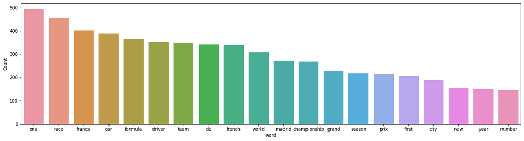

```python
freq_words(new_data['Lemmatized Words'], 20)
```

Another visualization we can utilize is a Word Cloud. I followed a simple [tutorial](https://towardsdatascience.com/simple-wordcloud-in-python-2ae54a9f58e5) to create the below Word Cloud.

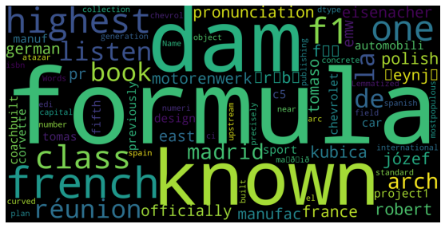

```python
import matplotlib.pyplot as plt
%matplotlib inline
from wordcloud import WordCloud

wordcloud = WordCloud(width=2000, height=1000, margin=0).generate(str(new_data['Lemmatized Words']))
plt.figure(figsize=(20, 5))
plt.imshow(wordcloud)
plt.axis("off")
plt.show()
```

## Building a LDA Model

The two main articles I used to understand how gensim can help build LDA models were [Topic Modeling with Gensim (Python)](https://www.machinelearningplus.com/nlp/topic-modeling-gensim-python/) and [Gensim Tutorial – A Complete Beginners Guide](https://www.machinelearningplus.com/nlp/gensim-tutorial/#11howtocreatetopicmodelswithlda). Both of these included code on how to create the bag of words corpus, dictionary and visualisations.

```python
import gensim
from gensim import corpora

import pyLDAvis
import pyLDAvis.gensim
```

```python
common_words = pd.Series(new_data['Lemmatized Words']).apply(lambda x: x.split())
```

To create an LDA model we need two inputs, *a dictionary object* and a *bag-of-words (Corpus)*.

- A dictionary in Gensim represents a map of all words (tokens) to its unique id.
- Using the dictionary we can create a bag-of-words corpus in the form of (word_id, word_frequency).

```python
# Create our Dictionary
dictionary = corpora.Dictionary(common_words)

# Create our Bag of Words Corpus
corpus = [dictionary.doc2bow(words) for words in common_words]
```

We can use this two inputs to train our LDA model. There are some other parameters we can update:

- num_topics (The number of topics we want to output)
- chunksize (The number of documents to be used in each training chunk)
- passes (The number of training passes)

These can also be found in the Gensim [documentation](https://radimrehurek.com/gensim/models/ldamodel.html).

```python
# Creating our LDA Model
LDA = gensim.models.ldamodel.LdaModel
lda_model = LDA(corpus=corpus, id2word=dictionary, num_topics=5, random_state=100, passes=50, per_word_topics=True)
```

```python
lda_model.print_topics()
```

```
[(0,
  '0.028*"dam" + 0.012*"arch" + 0.006*"corvette" + 0.006*"ft" + 0.005*"car" + 0.005*"design" + 0.005*"le" + 0.004*"z06" + 0.004*"model" + 0.004*"built"'),
 (1,
  '0.020*"isbn" + 0.019*"digit" + 0.012*"book" + 0.010*"check" + 0.008*"number" + 0.007*"–" + 0.006*"international" + 0.006*"publisher" + 0.006*"isbns" + 0.006*"group"'),
 (2,
  '0.022*"kubica" + 0.012*"race" + 0.012*"season" + 0.008*"car" + 0.008*"driver" + 0.008*"formula" + 0.007*"team" + 0.007*"first" + 0.007*"grand" + 0.007*"prix"'),
 (3,
  '0.019*"race" + 0.017*"one" + 0.016*"formula" + 0.016*"car" + 0.015*"driver" + 0.014*"team" + 0.012*"championship" + 0.009*"grand" + 0.009*"prix" + 0.008*"world"'),
 (4,
  '0.015*"france" + 0.012*"french" + 0.010*"madrid" + 0.010*"de" + 0.007*"city" + 0.005*"world" + 0.005*"century" + 0.004*"la" + 0.004*"one" + 0.004*"national"')]
```

## Topics Visualization

```python
pyLDAvis.enable_notebook()
vis = pyLDAvis.gensim.prepare(lda_model, corpus, dictionary)
vis
```

[interactive chart not shown]